# Question

Some quantity ($y$) is varying in time ($t$), following a temporal [sinusoidal function](https://en.wikipedia.org/wiki/Sine_wave) parameterized with 4 parameters:

$$y(t) ~=~
A\sin\left(\frac{2\pi}{P}(t+L)\right)+D$$

- Amplitude $A$, where $A>0$
  - Amplitude is the “vertical stretch” factor. It is **half the difference of the max and min** (of the $y$ values),
  - A negative $A$ would cause a vertical reflection. However, an equivalent transformation would be caused by shifting “horizontally” (in time) by half a period, so there is no loss of generality by forcing $A$ to be positive.
  - The amplitude might indicate changes in pressure, position, temperature, or many other types of quantities.
  - The [wikipedia article on amplitude](https://en.wikipedia.org/wiki/Amplitude#Semi-amplitude) refers to $A$ as the semi-amplitude.
- Period $P$, where $P>0$
  - Period is a “horizontal stretch” factor.
  - It is the **difference in time between neighboring peaks**.
  - Another symbol, $T$, is often used for period.
  - Period has units of time, typically seconds.
  - The [frequency](https://en.wikipedia.org/wiki/Frequency) is the reciprocal of $P$, so $f=\frac{1}{P}$. Frequency has units of [hertz](https://en.wikipedia.org/wiki/Hertz).
  - The [angular frequency](https://en.wikipedia.org/wiki/Angular_frequency) $\omega$ is in radians per second: $\omega~=~\frac{2\pi}{P}~=~2\pi f$
  - If the independent variable is spatial rather than temporal, the analogous term to “period” is “[wavelength](https://en.wikipedia.org/wiki/Wavelength)”; often $\lambda$ is used for wavelength.
  - Most physical waves (like sound and light) vary in space and time, so they have both wavelength and period, which are related by the speed ($v$) of the wave: $v=\frac{\lambda}{P}$
- Leftward shift $L$, where $0\le L<P$. All points along the sine function are shifted backwards (in time) by $L$.
  - When $t=0$, it is kind of like $L$ time has already passed (compared to the parent sine function).
  - Like $A$, the parameter $L$ does not need to be constrained (between 0 and $P$), but any sinusoidal wave can be generated with this constraint.
  - This parameter, $L$, has units of time.
  - Many textbooks will incorrectly/confusingly refer to this as the “phase shift”.
  - The phase shift, $\phi$, has units of radians: $\phi=\frac{2\pi L}{P}$.
- [Vertical shift](https://manual.audacityteam.org/man/dc_offset.html) $D$
  - The vertical shift is **half the sum of the max and min**, which is the average of the max and min.
  - This vertical shift is called [DC offset or DC bias](https://en.wikipedia.org/wiki/DC_bias) in sound recording.
  - The midline at $y=D$ is halfway between the [crests and troughs](https://en.wikipedia.org/wiki/Crest_and_trough).

Those four parameters were randomly assigned values, producing the graph below.

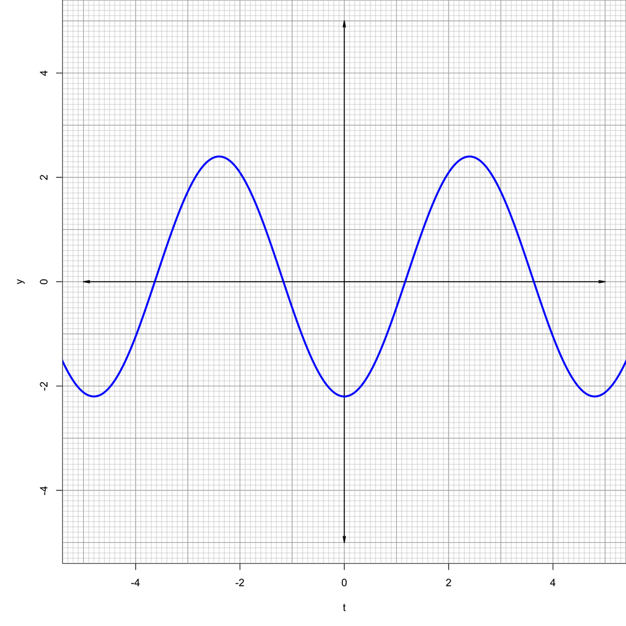

Estimate the **amplitude** of the [sinusoidal](https://www.khanacademy.org/math/algebra2/x2ec2f6f830c9fb89:trig/x2ec2f6f830c9fb89:amp-mid-period/a/midline-amplitude-and-period-review) function graphed above.

# Solution

The amplitude of a [sinusoidal function](https://en.wikipedia.org/wiki/Sine_wave) is half the difference between the maximum $y$ and the minimum $y$.

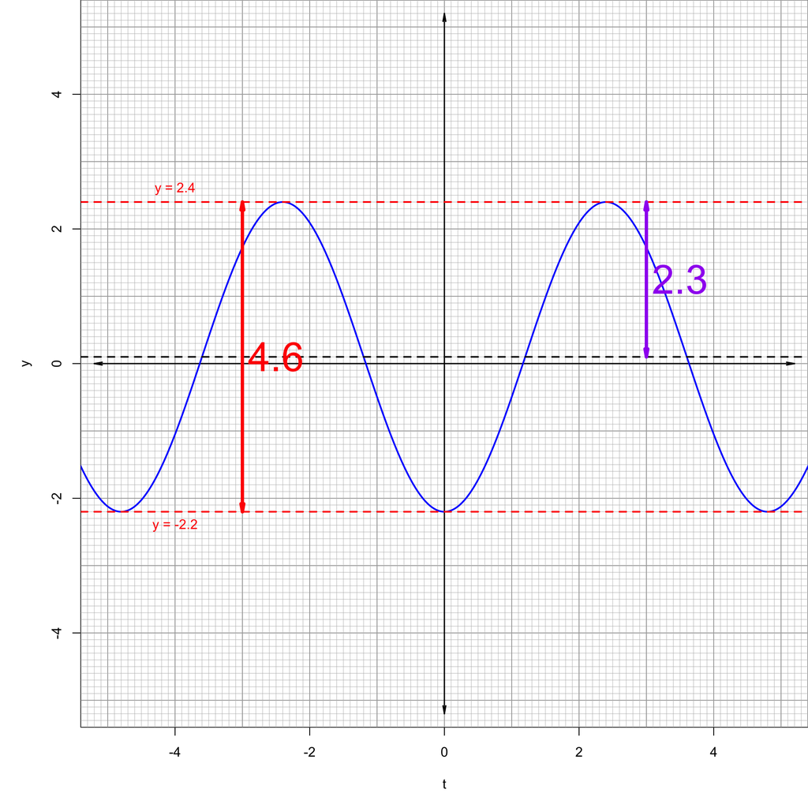

$$A~=~\frac{(2.4)-(-2.2)}{2} ~=~
\frac{4.6}{2} ~=~ 2.3$$

The amplitude is 2.3.

This exact function could be plotted with the following algebraic definition:
$$y(t) = 2.3
\sin\left(\frac{2\pi}{4.8}(t+3.6)\right)+(0.1)$$

The amplitude is 2.3; the period is 4.8; the horizontal shift is left by 3.6; and the midline is $y=0.1$.

# Meta-information

extype: num exsolution: 2.3 exname: estimate_amplitude extol: 0.1